FFHS DAS Data Science  
Semesterarbeit FS20  
Iwan Imsand

Statistische Datenanalyse (StatDa)  
**Nach der fünften Präsenz**

# Zeitreihenanalyse

## Fragestellung

- **Wie entwickelt sich die Anzahl Trips in den nächsten 2 Jahren?**

## Daten für die Analyse

Als Grundlage für nachfolgende Analyse dienen die folgenden Daten:

| Dateiname | Beschreibung |
| --- | --- |
| **`summary-daily-subscribers_only-citibike-tripweather.parquet`** | Enthält eine aggregierte Zusammenfassung pro Tag über alle Jahre. Es wurden nur Jahresmitglieder berücksichtigt! |

Die vorhandenen Merkmale wurden in 1_0_SemArb-StatDa_Deskriptive-Analyse.ipynb eingehender beschrieben, daher wird hier darauf verzichtet.

Alle Dateien befinden sich im Pfad `./../data/citibike/tripdata/`.

```python
import os
import pandas as pd
import numpy as np

import statsmodels.api as sm
from statsmodels.tsa.seasonal import seasonal_decompose

import matplotlib.pyplot as plt
import matplotlib
import seaborn as sns

# Auto Arima Forecast
from statsmodels.tsa.arima_model import ARIMA
import pmdarima as pm
```

```python
%matplotlib inline
```

```python
pd.options.display.float_format = '{:.5f}'.format
```

```python
path_tripdata = './../data/citibike/tripdata'
```

```python
SEED = 10142101
```

```python
df = pd.read_parquet(os.path.join(path_tripdata, 'summary-daily-subscribers_only-citibike-tripweather.parquet'))
```

Es interessiert nur die Anzahl der Trips, daher wird nur die Spalte 'Trip count' benötigt.

```python
df = df['Trip count']
```

Um die Analyse zu vereinfachen, werden die Anzahl der Trips monatlich summiert.

```python
df = df.resample('m').sum()
```

Und es werden nur komplette Jahre in die Analyse einbezogen, also 2014 bis und mit 2019.

```python
df = df['2014':'2019']
```

```python
print('Anzahl Monate im Datensatz: {}'.format(df.count()))
```

```
Anzahl Monate im Datensatz: 72
```

```python
df.head()
```

```
Date
2014-01-31   292499.00000
2014-02-28   217282.00000
2014-03-31   415577.00000
2014-04-30   606919.00000
2014-05-31   757483.00000
Freq: M, Name: Trip count, dtype: float64
```

```python
df.describe()
```

```
count        72.00000
mean    1051024.02778
std      454118.99769
min      194288.00000
25%      757952.50000
50%      939154.00000
75%     1423252.00000
max     2007240.00000
Name: Trip count, dtype: float64
```

## Analyse

Für das Verständnis und die Analyse mit Python haben mir die folgenden Resourcen sehr geholfen:

- https://www.machinelearningplus.com/time-series/time-series-analysis-python/
- https://www.machinelearningplus.com/time-series/arima-model-time-series-forecasting-python/

### Visualisierung

In einem ersten Schritt sollen die vorhandenen Daten visualisiert werden.

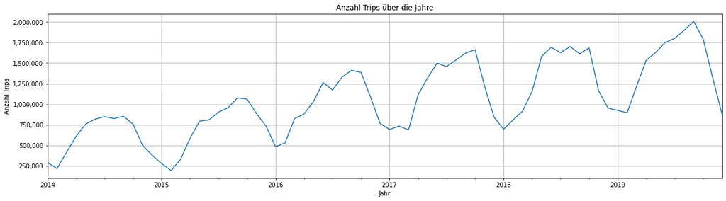

```python
fig = plt.figure(figsize=(20, 5))

ax = fig.add_subplot()
ax.set_ylabel('Anzahl Trips')
ax.set_title('Anzahl Trips über die Jahre')
_= df.plot(ax=ax, y='Anzahl Trips', color='tab:blue')
plt.grid(True)
ax.get_yaxis().set_major_formatter(matplotlib.ticker.FuncFormatter(lambda x, p: format(int(x), ',')))

plt.xlabel('Jahr')
plt.show()
```

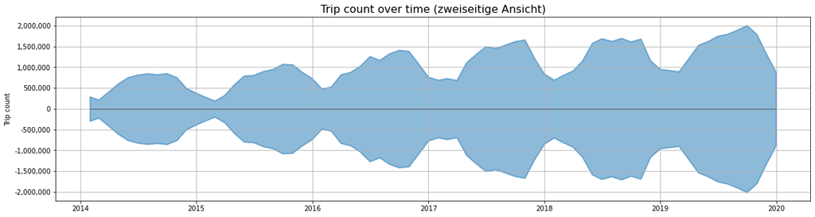

```python
fig, ax = plt.subplots(1, 1, figsize=(20, 5))
plt.fill_between(df.index, y1=df.values, y2=-df.values, alpha=0.5, linewidth=2, color='tab:blue')
plt.title('Trip count over time (zweiseitige Ansicht)', fontsize=16)
plt.hlines(y=0, xmin=np.min(df.index), xmax=np.max(df.index), linewidth=0.5)
plt.grid(True)
ax.get_yaxis().set_major_formatter(matplotlib.ticker.FuncFormatter(lambda x, p: format(int(x), ',')))
ax.set_ylabel('Trip count')
plt.show()
```

Es ist zu sehen das ein Wachstum vorhanden ist.

### Saisonalität

```python
years = df.index.year.unique()
```

```python
np.random.seed(SEED)
colors = np.random.choice(list(matplotlib.colors.XKCD_COLORS.keys()), len(years), replace=False)
```

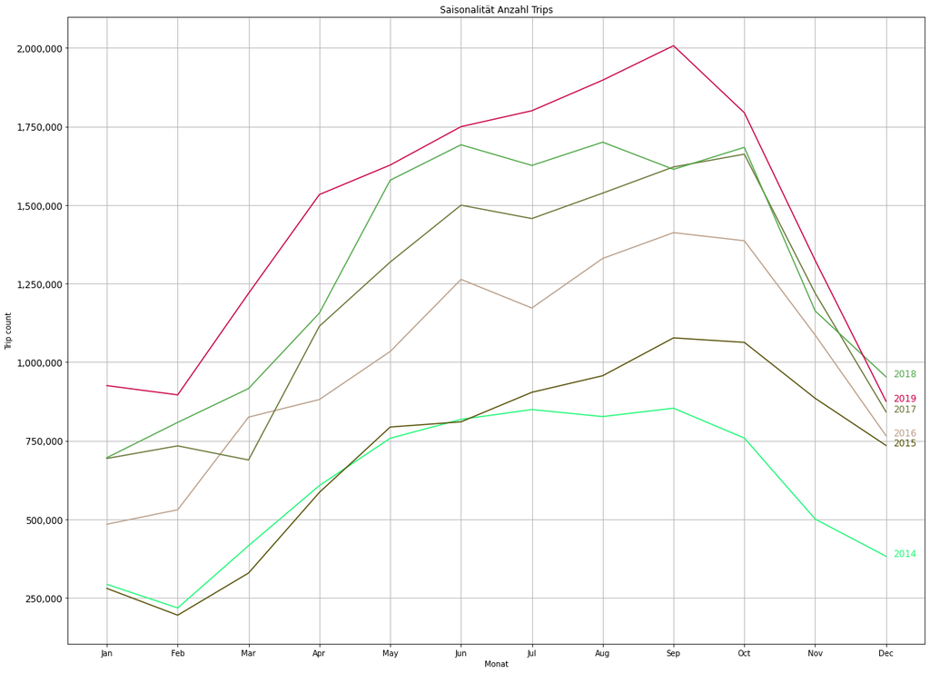

```python
fig = plt.figure(figsize=(20,15))
ax = fig.add_subplot()
for i, y in enumerate(years):
    color=colors[i]
    year=str(y)
    plt.plot(df[year].index.strftime('%b'), df[year].values, color=color, label=year)
    plt.text(df[year].shape[0]-.9, df[year].values[-1:][0], y, fontsize=12, color=color)

ax.get_yaxis().set_major_formatter(matplotlib.ticker.FuncFormatter(lambda x, p: format(int(x), ',')))
ax.set_ylabel('Trip count')

plt.title('Saisonalität Anzahl Trips')
plt.yticks(fontsize=12)
plt.xlabel('Monat')
plt.grid(True)
plt.show()
```

Es ist ersichtlich, dass im Januar wenige Trips gefahren werden und je nach Jahr im Februar der Tiefpunkt erreicht wird. Ab Februar steigen die Trips dann aber wieder kontinuierlich an. Im Juli gibt es wieder einen Einbruch, um danach noch mehr anzusteigen. Ab September beginnen die Anzahl Trips aber wieder zu sinken und fallen zurück auf das Niveau im Januar.

### Boxplots zur Erkennung von Saisonalität und Trend

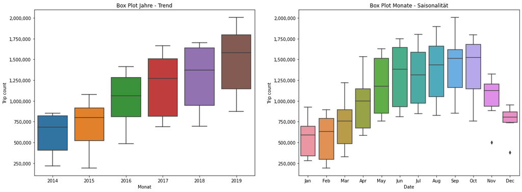

```python
fig, axes = plt.subplots(1, 2, figsize=(20,7))
sns.boxplot(x=df.index.year, y=df.values,ax=axes[0])
sns.boxplot(x=df.index.strftime('%b'), y=df.values)
for ax in axes:
    ax.get_yaxis().set_major_formatter(matplotlib.ticker.FuncFormatter(lambda x, p: format(int(x), ',')))
    ax.set_ylabel('Trip count')
axes[0].set_title('Box Plot Jahre - Trend')
axes[0].set_xlabel('Jahr')
axes[1].set_title('Box Plot Monate - Saisonalität')
axes[0].set_xlabel('Monat')
plt.show()
```

Anhand der Boxpots ist die Verteilung nach Jahr und Monat sehr deutlich zu erkennen. Der Trend ist klar steigend und während der Wintersaison werden die Bikes am wenigsten genutzt.

### Zerlegung in Komponenten

#### Additiv

Die Zeitreihe ist die Summe aus Trend, Zyklus und Saison.

```python
result_add = seasonal_decompose(df, model='additive', extrapolate_trend='freq')
```

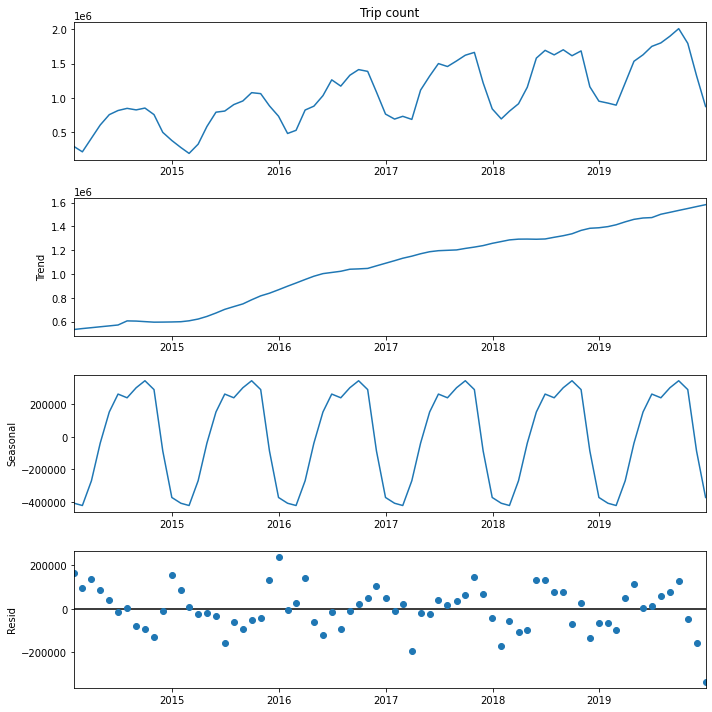

```python
plt.rcParams.update({'figure.figsize': (10,10)})
fig = result_add.plot()
plt.show()
```

#### Multiplikativ

Die Zeitreihe ist das Produkt aus Trend, Zyklus, Saison und Rest.

```python
result_mul = seasonal_decompose(df, model='multiplicative', extrapolate_trend='freq')
```

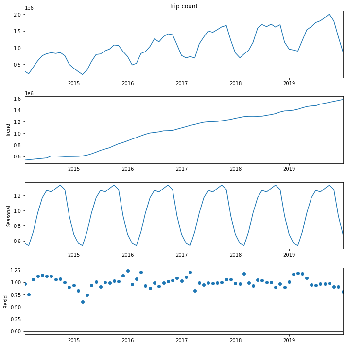

```python
plt.rcParams.update({'figure.figsize': (10,10)})
fig = result_mul.plot()
plt.show()
```

### Erstellung Dataframe mit den einzelnen Komponenten

```python
# Actual Values = Product of (Seasonal * Trend * Resid)
df_reconstructed = pd.concat([result_mul.seasonal, result_mul.trend, result_mul.resid, result_mul.observed], axis=1)
df_reconstructed.columns = ['season', 'trend', 'resid', 'actual_values']
df_reconstructed.head()
```

| Date | season | trend | resid | actual_values |
| --- | --- | --- | --- | --- |
| 2014-01-31 | 0.56601 | 533873.64360 | 0.96797 | 292499.00000 |
| 2014-02-28 | 0.53572 | 541382.56740 | 0.74917 | 217282.00000 |
| 2014-03-31 | 0.71976 | 548891.49121 | 1.05191 | 415577.00000 |
| 2014-04-30 | 0.96883 | 556400.41502 | 1.12589 | 606919.00000 |
| 2014-05-31 | 1.16928 | 563909.33882 | 1.14880 | 757483.00000 |

## Vorhersagen mit Auto ARIMA

```python
model = pm.auto_arima(df.values, start_p=1, start_q=1,
                      test='adf',       # use adftest to find optimal 'd'
                      max_p=3, max_q=3, # maximum p and q
                      m=1,              # frequency of series
                      d=None,           # let model determine 'd'
                      seasonal=False,   # No Seasonality
                      start_P=0,
                      D=0,
                      trace=True,
                      error_action='ignore',
                      suppress_warnings=True,
                      stepwise=True)
```

```
Performing stepwise search to minimize aic
Fit ARIMA(1,0,1)x(0,0,0,0) [intercept=True]; AIC=1947.331, BIC=1956.438, Time=0.022 seconds
Fit ARIMA(0,0,0)x(0,0,0,0) [intercept=True]; AIC=2083.081, BIC=2087.634, Time=0.004 seconds
Fit ARIMA(1,0,0)x(0,0,0,0) [intercept=True]; AIC=1967.433, BIC=1974.263, Time=0.009 seconds
Fit ARIMA(0,0,1)x(0,0,0,0) [intercept=True]; AIC=2034.027, BIC=2040.857, Time=0.009 seconds
Fit ARIMA(0,0,0)x(0,0,0,0) [intercept=False]; AIC=2215.093, BIC=2217.370, Time=0.002 seconds
Fit ARIMA(2,0,1)x(0,0,0,0) [intercept=True]; AIC=1939.591, BIC=1950.974, Time=0.018 seconds
Fit ARIMA(2,0,0)x(0,0,0,0) [intercept=True]; AIC=1937.687, BIC=1946.794, Time=0.012 seconds
Fit ARIMA(3,0,0)x(0,0,0,0) [intercept=True]; AIC=1939.436, BIC=1950.820, Time=0.017 seconds
Fit ARIMA(3,0,1)x(0,0,0,0) [intercept=True]; AIC=1941.382, BIC=1955.042, Time=0.035 seconds
Total fit time: 0.133 seconds
```

```python
print(model.summary())
```

```
                               SARIMAX Results
==============================================================================
Dep. Variable:                      y   No. Observations:                   72
Model:               SARIMAX(2, 0, 0)   Log Likelihood                -964.844
Date:                Sun, 21 Jun 2020   AIC                           1937.687
Time:                        18:06:57   BIC                           1946.794
Sample:                             0   HQIC                          1941.313
                                 - 72
Covariance Type:                  opg
==============================================================================
                 coef    std err          z      P>|z|      [0.025      0.975]
------------------------------------------------------------------------------
intercept   1.838e+05   5.01e+04      3.668      0.000    8.56e+04    2.82e+05
ar.L1          1.4528      0.121     12.016      0.000       1.216       1.690
ar.L2         -0.6303      0.125     -5.047      0.000      -0.875      -0.386
sigma2      2.409e+10      0.213   1.13e+11      0.000    2.41e+10    2.41e+10
===================================================================================
Ljung-Box (Q):                       64.66   Jarque-Bera (JB):                 0.17
Prob(Q):                              0.01   Prob(JB):                         0.92
Heteroskedasticity (H):               2.43   Skew:                            -0.10
Prob(H) (two-sided):                  0.03   Kurtosis:                         3.13
===================================================================================

Warnings:
[1] Covariance matrix calculated using the outer product of gradients (complex-step).
[2] Covariance matrix is singular or near-singular, with condition number 3.62e+26. Standard errors may be unstable.
```

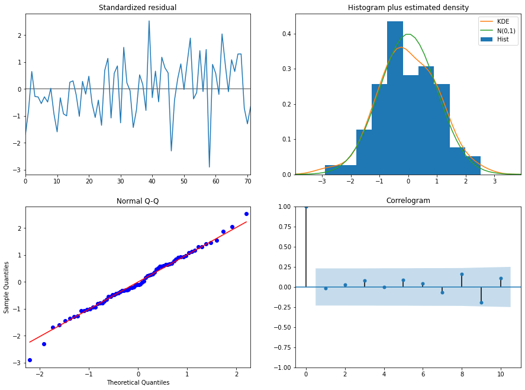

```python
model.plot_diagnostics(figsize=(15, 11))
plt.show()
```

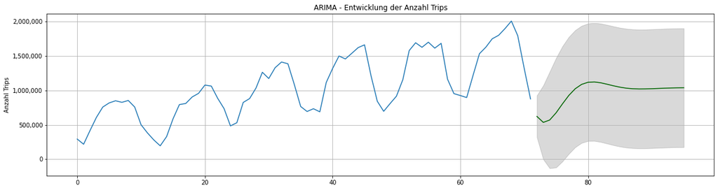

```python
n_periods = 24
fc, confint = model.predict(n_periods=n_periods, return_conf_int=True)
index_of_fc = np.arange(len(df.values), len(df.values)+n_periods)

# make series for plotting purpose
fc_series = pd.Series(fc, index=index_of_fc)
lower_series = pd.Series(confint[:, 0], index=index_of_fc)
upper_series = pd.Series(confint[:, 1], index=index_of_fc)

# Plot
plt.subplots(figsize=(20, 5))
plt.plot(df.values)
plt.plot(fc_series, color='darkgreen')
plt.fill_between(lower_series.index,
                 lower_series,
                 upper_series,
                 color='k', alpha=.15)

plt.gca().get_yaxis().set_major_formatter(matplotlib.ticker.FuncFormatter(lambda x, p: format(int(x), ',')))
plt.grid(True)

plt.ylabel('Anzahl Trips')
plt.title('ARIMA - Entwicklung der Anzahl Trips')
plt.show()
```

Die Vorhersagen sind in diesem Modell nicht sehr gut, sie setzen schon zu tief an und die Saisonalität scheint nicht berücksichtigt zu werden.

## Vorhersagen mit Auto SARIMA

```python
# Seasonal - fit stepwise auto-ARIMA
smodel = pm.auto_arima(df, start_p=1, start_q=1,
                         test='adf',
                         max_p=3, max_q=3, m=12,
                         start_P=0, seasonal=True,
                         d=None, D=1, trace=True,
                         error_action='ignore',
                         suppress_warnings=True,
                         stepwise=True)

print(smodel.summary())
```

```
Performing stepwise search to minimize aic
Fit ARIMA(1,1,1)x(0,1,1,12) [intercept=True]; AIC=1563.158, BIC=1573.546, Time=0.133 seconds
Fit ARIMA(0,1,0)x(0,1,0,12) [intercept=True]; AIC=1571.244, BIC=1575.399, Time=0.058 seconds
Fit ARIMA(1,1,0)x(1,1,0,12) [intercept=True]; AIC=1563.004, BIC=1571.314, Time=0.056 seconds
Fit ARIMA(0,1,1)x(0,1,1,12) [intercept=True]; AIC=1561.955, BIC=1570.265, Time=0.061 seconds
Fit ARIMA(0,1,0)x(0,1,0,12) [intercept=False]; AIC=1570.499, BIC=1572.577, Time=0.005 seconds
Fit ARIMA(0,1,1)x(0,1,0,12) [intercept=True]; AIC=1565.391, BIC=1571.624, Time=0.016 seconds
Fit ARIMA(0,1,1)x(1,1,1,12) [intercept=True]; AIC=1563.714, BIC=1574.102, Time=0.134 seconds
Fit ARIMA(0,1,1)x(0,1,2,12) [intercept=True]; AIC=1563.534, BIC=1573.922, Time=0.187 seconds
Fit ARIMA(0,1,1)x(1,1,0,12) [intercept=True]; AIC=1561.955, BIC=1570.266, Time=0.066 seconds
Fit ARIMA(0,1,1)x(1,1,2,12) [intercept=True]; AIC=1565.233, BIC=1577.698, Time=0.431 seconds
Fit ARIMA(0,1,0)x(0,1,1,12) [intercept=True]; AIC=1563.105, BIC=1569.338, Time=0.053 seconds
Fit ARIMA(0,1,2)x(0,1,1,12) [intercept=True]; AIC=1563.512, BIC=1573.899, Time=0.104 seconds
Fit ARIMA(1,1,0)x(0,1,1,12) [intercept=True]; AIC=1562.492, BIC=1570.802, Time=0.062 seconds
Fit ARIMA(1,1,2)x(0,1,1,12) [intercept=True]; AIC=1564.802, BIC=1577.267, Time=0.210 seconds
Near non-invertible roots for order (1, 1, 2)(0, 1, 1, 12); setting score to inf (at least one inverse root too close to the border of the unit circle: 0.996)
Total fit time: 1.583 seconds
                                     SARIMAX Results
==========================================================================================
Dep. Variable:                                  y   No. Observations:                   72
Model:             SARIMAX(0, 1, 1)x(0, 1, 1, 12)   Log Likelihood                -776.978
Date:                            Sun, 21 Jun 2020   AIC                           1561.955
Time:                                    18:06:59   BIC                           1570.265
Sample:                                         0   HQIC                          1565.199
                                             - 72
Covariance Type:                              opg
==============================================================================
                 coef    std err          z      P>|z|      [0.025      0.975]
------------------------------------------------------------------------------
intercept   2575.2333   9807.762      0.263      0.793   -1.66e+04    2.18e+04
ma.L1         -0.2780      0.148     -1.877      0.061      -0.568       0.012
ma.S.L12      -0.3029      0.139     -2.186      0.029      -0.574      -0.031
sigma2      1.808e+10      0.008   2.17e+12      0.000    1.81e+10    1.81e+10
===================================================================================
Ljung-Box (Q):                       52.74   Jarque-Bera (JB):                 1.69
Prob(Q):                              0.09   Prob(JB):                         0.43
Heteroskedasticity (H):               1.46   Skew:                            -0.28
Prob(H) (two-sided):                  0.40   Kurtosis:                         2.40
===================================================================================

Warnings:
[1] Covariance matrix calculated using the outer product of gradients (complex-step).
[2] Covariance matrix is singular or near-singular, with condition number 3.78e+31. Standard errors may be unstable.
```

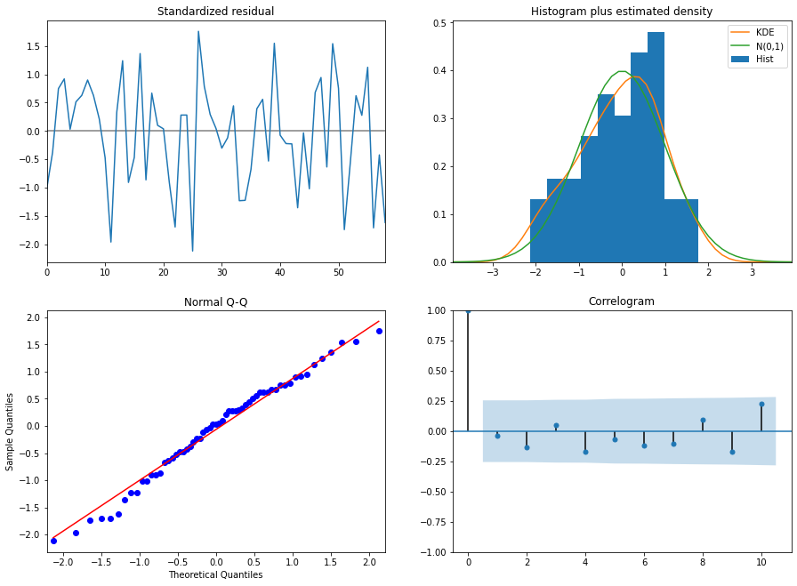

```python
smodel.plot_diagnostics(figsize=(15, 11))
plt.show()
```

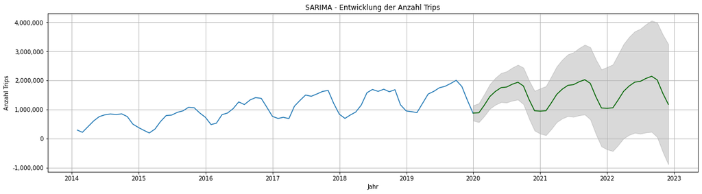

```python
n_periods = 36
fitted, confint = smodel.predict(n_periods=n_periods, return_conf_int=True)
index_of_fc = pd.date_range(df.index[-1], periods = n_periods, freq='MS')

# make series for plotting purpose
fitted_series = pd.Series(fitted, index=index_of_fc)
lower_series = pd.Series(confint[:, 0], index=index_of_fc)
upper_series = pd.Series(confint[:, 1], index=index_of_fc)

# Plot
plt.subplots(figsize=(20, 5))
plt.plot(df)
plt.plot(fitted_series, color='darkgreen')
plt.fill_between(lower_series.index,
                 lower_series,
                 upper_series,
                 color='k', alpha=.15)

plt.gca().get_yaxis().set_major_formatter(matplotlib.ticker.FuncFormatter(lambda x, p: format(int(x), ',')))
plt.grid(True)
plt.title('SARIMA - Entwicklung der Anzahl Trips')
plt.ylabel('Anzahl Trips')
plt.xlabel('Jahr')

plt.savefig('test.svg', dpi=150, transparent=True)
plt.show()
```

Dieses Modell scheint schon bessere Vorhersagen machen zu können. Auch der Trend wird leicht berücksichtigt, das Maximum zwischen 2021 und 2022 ist höher als das Maximum zwischen 2020 und 2021.

**Im Plot ist ersichtlich, wie sich die Anzahl Trips in den nächsten zwei bis 3 Jahren entwickeln könnte.**